# Heart Transplant Survival Analysis: Fixed vs. Time-Varying Approaches

Survival Analysis Team

May 07, 2025

## 1. Introduction

This report examines survival outcomes in heart transplant patients from Brigham and Women’s Hospital. We compare traditional Cox proportional hazards models with time-varying treatment models to better account for the timing of transplantation and avoid immortal time bias.

Immortal time bias occurs when the time period between cohort entry and treatment initiation is misclassified regarding the subject’s treatment status. In our context, patients must survive long enough to receive a heart transplant, creating a period of “immortal time” for the treated group.

## 2. Data Preparation

```r
# Load the raw data
df_bwh_raw <- readRDS(here("data/bwh-heart-transplant/cleaned_bwh_transplant_data.rds"))

# Basic data preparation
df_bwh <- df_bwh_raw %>%
  filter(!is.na(time_to_event)) %>%
  mutate(
    trt = transplant,
    # Create factor versions of categorical variables for better visualization
    transplant_factor = factor(transplant, levels = c(0, 1), labels = c("No", "Yes")),
    ventilation_factor = factor(ventilation, levels = c(FALSE, TRUE), labels = c("No", "Yes")),
    event_factor = factor(event, levels = c(0, 1), labels = c("Censored", "Death"))
  )

# Quick look at the data structure
glimpse(df_bwh)
```

```
Rows: 1,202
Columns: 28
$ subject            <int> 1, 2, 3, 4, 5, 6, 7, 8, 9, 10, 11, 12, 13, 14, 15, …
$ listing_date       <date> 1987-05-07, 1987-06-17, 1987-08-07, 1987-10-05, 19…
$ year               <dbl> 0.0000000, 0.1122519, 0.2518823, 0.4134155, 0.41615…
$ transplant_date    <date> 1987-10-08, 1988-07-22, 1988-06-14, 1987-11-20, 19…
$ death_date         <date> 2015-08-30, 2004-06-06, 2006-05-22, 2011-01-01, 20…
$ censor_date        <date> 1987-10-08, 1988-08-12, 1988-06-14, 1987-11-20, 19…
$ transplant         <lgl> TRUE, TRUE, TRUE, TRUE, TRUE, TRUE, TRUE, TRUE, TRU…
$ time_to_event      <dbl> 339.7503285, 203.6465177, 225.4599212, 278.8764783,…
$ event              <dbl> 1, 1, 1, 1, 1, 0, 0, 0, 1, 0, 1, 0, 1, 1, 1, 1, 1, …
$ time_to_tx         <dbl> 5.0591327, 13.1734560, 10.2496715, 1.5111695, 2.693…
$ age                <dbl> 50, 52, 57, 19, 35, 23, 56, 59, 20, 54, 25, 39, 39,…
$ gender             <chr> "m", "m", "m", "f", "m", "f", "m", "m", "m", "m", "…
$ race               <chr> "white, non-hispanic", "white, non-hispanic", "whit…
$ blood_type         <chr> "B", "AB", "O", "O", "O", "O", "O", "A", "A", "A", …
$ status_listing     <chr> "not reported", "not reported", "not reported", "no…
$ diagnosis          <chr> "dilated myopathy: idiopathic", "coronary artery di…
$ height_cm          <dbl> 167, 177, 177, NA, NA, 165, 152, 182, 180, 177, 165…
$ weight_kg          <dbl> 64, 77, 78, NA, NA, 58, 70, 82, 65, 93, 57, 84, 80,…
$ bmi                <dbl> 22.9481, 24.5779, 24.8971, NA, NA, 21.3039, 30.2978…
$ ventilation        <lgl> FALSE, FALSE, FALSE, FALSE, FALSE, FALSE, FALSE, FA…
$ ecmo               <lgl> FALSE, FALSE, FALSE, FALSE, FALSE, FALSE, FALSE, FA…
$ iabp               <lgl> FALSE, FALSE, FALSE, FALSE, FALSE, FALSE, FALSE, FA…
$ inotropes          <lgl> FALSE, FALSE, FALSE, FALSE, FALSE, FALSE, FALSE, FA…
$ support_device     <lgl> FALSE, FALSE, FALSE, FALSE, FALSE, FALSE, FALSE, FA…
$ trt                <lgl> TRUE, TRUE, TRUE, TRUE, TRUE, TRUE, TRUE, TRUE, TRU…
$ transplant_factor  <fct> NA, NA, NA, NA, NA, NA, NA, NA, NA, NA, NA, NA, NA,…
$ ventilation_factor <fct> No, No, No, No, No, No, No, No, No, No, No, No, No,…
$ event_factor       <fct> Death, Death, Death, Death, Death, Censored, Censor…
```

### 2.1 Data Summary

```r
# Create a nicer summary statistics table by transplant status
df_summary <- df_bwh %>%
  # Select variables of interest
  select(event, age, bmi, blood_type, ventilation, support_device, transplant_factor) %>%
  # Group by transplant status
  group_by(transplant_factor) %>%
  # Compute summary statistics
  summarise(
    `Sample Size` = n(),
    `Death Events (%)` = paste0(sum(event == 1), " (", round(mean(event) * 100, 1), "%)"),
    `Age (mean ± SD)` = paste0(round(mean(age, na.rm = TRUE), 1), " ± ", round(sd(age, na.rm = TRUE), 1)),
    `BMI (mean ± SD)` = paste0(round(mean(bmi, na.rm = TRUE), 1), " ± ", round(sd(bmi, na.rm = TRUE), 1)),
    `Ventilation (%)` = paste0(sum(ventilation, na.rm = TRUE), " (", round(mean(ventilation, na.rm = TRUE) * 100, 1), "%)"),
    `Support Device (%)` = paste0(sum(support_device, na.rm = TRUE), " (", round(mean(support_device, na.rm = TRUE) * 100, 1), "%)")
  )

# Display the table using kable for nicer formatting
kable(df_summary, caption = "Patient Characteristics by Transplant Status") %>%
  kable_styling(bootstrap_options = c("striped", "hover", "condensed"), full_width = FALSE) %>%
  add_header_above(c(" " = 1, "Patient Characteristics" = 6))
```

Patient Characteristics by Transplant Status

| transplant_factor | Patient Characteristics Sample Size | Patient Characteristics Death Events (%) | Patient Characteristics Age (mean ± SD) | Patient Characteristics BMI (mean ± SD) | Patient Characteristics Ventilation (%) | Patient Characteristics Support Device (%) |
| --- | --- | --- | --- | --- | --- | --- |
| NA | 1202 | 454 (37.8%) | 49.9 ± 12 | 25.9 ± 4.7 | 20 (1.7%) | 158 (13.1%) |

## 3. Exploratory Analysis

### 3.1 Timing of Transplantation

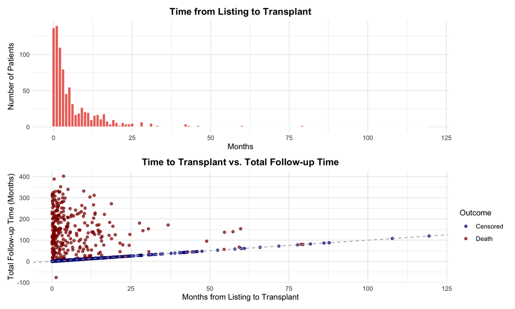

```r
# Create a more informative plot of transplant timing
p1 <- ggplot(df_bwh %>% filter(transplant == 1), aes(x = time_to_tx)) +
  geom_histogram(binwidth = 1, fill = transplant_colors["Yes"], color = "white", alpha = 0.8) +
  labs(title = "Time from Listing to Transplant",
       x = "Months",
       y = "Number of Patients") +
  theme_minimal() +
  theme(plot.title = element_text(hjust = 0.5, face = "bold"))

p2 <- ggplot(df_bwh %>% filter(transplant == 1),
       aes(x = time_to_tx, y = time_to_event, color = factor(event))) +
  geom_point(alpha = 0.7) +
  geom_abline(intercept = 0, slope = 1, linetype = "dashed", color = "darkgray") +
  scale_color_manual(values = c("0" = "darkblue", "1" = "darkred"),
                     labels = c("Censored", "Death"),
                     name = "Outcome") +
  labs(title = "Time to Transplant vs. Total Follow-up Time",
       x = "Months from Listing to Transplant",
       y = "Total Follow-up Time (Months)") +
  theme_minimal() +
  theme(plot.title = element_text(hjust = 0.5, face = "bold"))

# Combine the plots
p1 / p2
```

The top histogram shows the distribution of time from waiting list entry to transplantation. The bottom scatter plot displays the relationship between transplant timing and total follow-up time, with points above the dashed line representing patients who survived beyond their transplant.

## 4. Time-Varying Treatment Analysis

### 4.1 Create Time-Varying Dataset

```r
# Implementation of the function to create time-varying dataset
create_time_varying_dataset <- function(data,
                                      event_time,
                                      event,
                                      tx_time,
                                      covariates = NULL,
                                      id_col = "id") {

  # Input validation
  if (!event_time %in% colnames(data)) {
    stop(paste("Event time column", event_time, "not found in data"))
  }
  if (!event %in% colnames(data)) {
    stop(paste("Event indicator column", event, "not found in data"))
  }
  if (!tx_time %in% colnames(data)) {
    stop(paste("Treatment time column", tx_time, "not found in data"))
  }
  if (!id_col %in% colnames(data)) {
    stop(paste("ID column", id_col, "not found in data"))
  }

  # Handle cases where covariates is NULL
  if (is.null(covariates)) {
    covariates <- setdiff(colnames(data),
                          c(event_time, event, tx_time, id_col))
  } else {
    # Validate that all specified covariates exist
    missing_covs <- setdiff(covariates, colnames(data))
    if (length(missing_covs) > 0) {
      stop(paste("Covariates not found in data:",
                 paste(missing_covs, collapse = ", ")))
    }
  }

  # Create empty result dataframe
  result <- data.frame()

  # Process each subject
  for (i in 1:nrow(data)) {
    # Extract values for current subject
    row_data <- data[i, , drop = FALSE]
    t_event <- row_data[[event_time]]
    event_status <- row_data[[event]]
    t_tx <- row_data[[tx_time]]

    # Skip rows with NA event times
    if (is.na(t_event)) {
      warning(paste("Skipping row", i, "due to missing event time"))
      next
    }

    # Check for NA or missing tx time - treat as infinity
    if (is.na(t_tx)) {
      t_tx <- Inf
    }

    # Case 1: Subject did not receive treatment before event/censoring
    # This includes the case where treatment happens at the same time as event
    if (t_event <= t_tx) {
      new_row <- row_data
      new_row$tstart <- 0
      new_row$tstop <- t_event
      new_row$status <- event_status
      new_row$trt <- 0  # Not treated during observation period

      # Add to result
      result <- rbind(result, new_row)
    }
    # Case 2: Subject received treatment before event/censoring
    else {
      # First interval: from 0 to treatment time
      new_row1 <- row_data
      new_row1$tstart <- 0
      new_row1$tstop <- t_tx
      new_row1$status <- 0  # No event in this interval
      new_row1$trt <- 0     # Not treated yet

      # Second interval: from treatment time to event/censoring
      new_row2 <- row_data
      new_row2$tstart <- t_tx
      new_row2$tstop <- t_event
      new_row2$status <- event_status
      new_row2$trt <- 1     # Treated in this interval

      # Add both rows to result
      result <- rbind(result, new_row1, new_row2)
    }
  }

  # Ensure time intervals are valid (no zero-length intervals)
  result <- result[result$tstop > result$tstart, ]

  # Select only needed columns
  cols_to_keep <- unique(c(id_col, "tstart", "tstop", "status", "trt", covariates))
  result <- result[, cols_to_keep]

  return(result)
}
```

```r
# Create the time-varying dataset
df_bwh_timevar <- create_time_varying_dataset(
  data = df_bwh,
  event_time = "time_to_event",
  event = "event",
  tx_time = "time_to_tx",
  covariates = c("age", "ventilation", "year"),
  id_col = "subject"
)

# Examine the structure of the time-varying dataset
head(df_bwh_timevar, 10) %>%
  kable(caption = "First 10 rows of time-varying dataset") %>%
  kable_styling(bootstrap_options = c("striped", "hover", "condensed"),
                full_width = FALSE)
```

First 10 rows of time-varying dataset

| subject | tstart | tstop | status | trt | age | ventilation | year |
| --- | --- | --- | --- | --- | --- | --- | --- |
| 1 | 0.000000 | 5.059133 | 0 | 0 | 50 | FALSE | 0.0000000 |
| 1 | 5.059133 | 339.750329 | 1 | 1 | 50 | FALSE | 0.0000000 |
| 2 | 0.000000 | 13.173456 | 0 | 0 | 52 | FALSE | 0.1122519 |
| 2 | 13.173456 | 203.646518 | 1 | 1 | 52 | FALSE | 0.1122519 |
| 3 | 0.000000 | 10.249671 | 0 | 0 | 57 | FALSE | 0.2518823 |
| 3 | 10.249671 | 225.459921 | 1 | 1 | 57 | FALSE | 0.2518823 |
| 4 | 0.000000 | 1.511170 | 0 | 0 | 19 | FALSE | 0.4134155 |
| 4 | 1.511170 | 278.876478 | 1 | 1 | 19 | FALSE | 0.4134155 |
| 5 | 0.000000 | 2.693824 | 0 | 0 | 35 | FALSE | 0.4161533 |
| 5 | 2.693824 | 352.036794 | 1 | 1 | 35 | FALSE | 0.4161533 |

```r
# Summary of the time-varying dataset
summary_tv <- data.frame(
  "Original rows" = nrow(df_bwh),
  "Time-varying rows" = nrow(df_bwh_timevar),
  "Number of patients" = length(unique(df_bwh_timevar$subject)),
  "Number with treatment" = sum(df_bwh$transplant),
  "Number of events" = sum(df_bwh_timevar$status)
)

kable(t(summary_tv), col.names = "Value") %>%
  kable_styling(bootstrap_options = c("striped", "hover", "condensed"),
                full_width = FALSE)
```

|  | Value |
| --- | --- |
| Original.rows | 1202 |
| Time.varying.rows | 1788 |
| Number.of.patients | 1201 |
| Number.with.treatment | 881 |
| Number.of.events | 453 |

### 4.2 Cox Models Comparison

```r
# Fixed treatment Cox model
fit_fixed <- coxph(
  Surv(time_to_event, event) ~ (age + ventilation + year) * trt,
  data = df_bwh,
  ties = "breslow"
)

# Time-varying treatment Cox model
fit_timevarying <- coxph(
  Surv(tstart, tstop, status) ~ (age + ventilation + year) * trt,
  data = df_bwh_timevar,
  ties = "breslow"
)

# Extract model summaries
summary_fixed <- summary(fit_fixed)
summary_timevar <- summary(fit_timevarying)

# Display summaries using kable for better formatting
tidy_fixed <- tidy(fit_fixed, conf.int = TRUE, exponentiate = TRUE)
tidy_timevar <- tidy(fit_timevarying, conf.int = TRUE, exponentiate = TRUE)

# Format table for fixed model
kable(tidy_fixed %>%
        select(term, estimate, std.error, p.value, conf.low, conf.high) %>%
        rename(
          "Variable" = term,
          "HR" = estimate,
          "SE" = std.error,
          "p-value" = p.value,
          "95% CI Lower" = conf.low,
          "95% CI Upper" = conf.high
        ),
      caption = "Fixed Treatment Cox Model",
      digits = 3) %>%
  kable_styling(bootstrap_options = c("striped", "hover", "condensed"),
                full_width = FALSE)
```

Fixed Treatment Cox Model

| Variable | HR | SE | p-value | 95% CI Lower | 95% CI Upper |
| --- | --- | --- | --- | --- | --- |
| age | 1.036 | 0.008 | 0.000 | 1.019 | 1.052 |
| ventilationTRUE | 0.712 | 1.010 | 0.737 | 0.098 | 5.152 |
| year | 1.074 | 0.012 | 0.000 | 1.050 | 1.099 |
| trtTRUE | 2.481 | 0.535 | 0.090 | 0.869 | 7.083 |
| age:trtTRUE | 0.972 | 0.010 | 0.003 | 0.953 | 0.990 |
| ventilationTRUE:trtTRUE | 0.722 | 1.131 | 0.773 | 0.079 | 6.629 |
| year:trtTRUE | 0.980 | 0.013 | 0.114 | 0.955 | 1.005 |

```r
# Format table for time-varying model
kable(tidy_timevar %>%
        select(term, estimate, std.error, p.value, conf.low, conf.high) %>%
        rename(
          "Variable" = term,
          "HR" = estimate,
          "SE" = std.error,
          "p-value" = p.value,
          "95% CI Lower" = conf.low,
          "95% CI Upper" = conf.high
        ),
      caption = "Time-Varying Treatment Cox Model",
      digits = 3) %>%
  kable_styling(bootstrap_options = c("striped", "hover", "condensed"),
                full_width = FALSE)
```

Time-Varying Treatment Cox Model

| Variable | HR | SE | p-value | 95% CI Lower | 95% CI Upper |
| --- | --- | --- | --- | --- | --- |
| age | 1.030 | 0.008 | 0.000 | 1.014 | 1.046 |
| ventilationTRUE | 1.044 | 1.007 | 0.966 | 0.145 | 7.514 |
| year | 1.045 | 0.010 | 0.000 | 1.024 | 1.067 |
| trt | 3.257 | 0.536 | 0.028 | 1.139 | 9.313 |
| age:trt | 0.967 | 0.010 | 0.000 | 0.949 | 0.985 |
| ventilationTRUE:trt | 0.390 | 1.129 | 0.404 | 0.043 | 3.563 |
| year:trt | 1.044 | 0.013 | 0.001 | 1.019 | 1.070 |

### 4.3 Model Comparison

```r
# Create a comparison table
compare_df <- data.frame(
  Variable = tidy_fixed$term,

  # Fixed model
  HR_Fixed = sprintf("%.3f", tidy_fixed$estimate),
  CI_Fixed = sprintf("%.3f-%.3f", tidy_fixed$conf.low, tidy_fixed$conf.high),
  P_Fixed = sprintf("%.4f", tidy_fixed$p.value),

  # Time-varying model
  HR_TimeVar = sprintf("%.3f", tidy_timevar$estimate),
  CI_TimeVar = sprintf("%.3f-%.3f", tidy_timevar$conf.low, tidy_timevar$conf.high),
  P_TimeVar = sprintf("%.4f", tidy_timevar$p.value)
)

# Display the comparison table
kable(compare_df,
      col.names = c("Variable", "HR", "95% CI", "p-value", "HR", "95% CI", "p-value"),
      caption = "Comparison of Fixed vs. Time-Varying Treatment Models") %>%
  kable_styling(bootstrap_options = c("striped", "hover", "condensed"), full_width = FALSE) %>%
  add_header_above(c(" " = 1, "Fixed Treatment Model" = 3, "Time-Varying Treatment Model" = 3))
```

Comparison of Fixed vs. Time-Varying Treatment Models

| Variable | Fixed Treatment Model HR | Fixed Treatment Model 95% CI | Fixed Treatment Model p-value | Time-Varying Treatment Model HR | Time-Varying Treatment Model 95% CI | Time-Varying Treatment Model p-value |
| --- | --- | --- | --- | --- | --- | --- |
| age | 1.036 | 1.019-1.052 | 0.0000 | 1.030 | 1.014-1.046 | 0.0002 |
| ventilationTRUE | 0.712 | 0.098-5.152 | 0.7367 | 1.044 | 0.145-7.514 | 0.9662 |
| year | 1.074 | 1.050-1.099 | 0.0000 | 1.045 | 1.024-1.067 | 0.0000 |
| trtTRUE | 2.481 | 0.869-7.083 | 0.0897 | 3.257 | 1.139-9.313 | 0.0276 |
| age:trtTRUE | 0.972 | 0.953-0.990 | 0.0032 | 0.967 | 0.949-0.985 | 0.0005 |
| ventilationTRUE:trtTRUE | 0.722 | 0.079-6.629 | 0.7734 | 0.390 | 0.043-3.563 | 0.4040 |
| year:trtTRUE | 0.980 | 0.955-1.005 | 0.1141 | 1.044 | 1.019-1.070 | 0.0006 |